# machine_learning

2023-01-07

#### 1.[5 pts] Write code that produces a 10,000 x 1001 matrix (rows x cols) of random numbers drawn from N(0,1). Seed your code using the last 4 digits of your phone number (this number will be different for everyone). Every time you run the code, it should now yield the exact same (“random”) dataset.

```r
library(dplyr)
### fix seed for the random number generator
set.seed(2893)

### assign randomly generated number from normally distributed data to fill a 10000X1001 matrix m
m <- matrix(data = rnorm(10000*1001)  , nrow= 10000 , ncol = 1001)
```

#### 2.Treat the first column as “y” and the remaining 1000 columns as x’s.

```r
### assign first column to y
y <- m[,1]

### assign rest of the columns to X's
x <- m[,2:1001]
```

#### 3. Regress y on x’s. Is an intercept needed? Why? Why not?

```r
regression <- lm(y~x[,1:1000]-1)
```

I think there shouldn’t be an intercept, because both Xs and Ys are generated from N~(0,1), since that regression line always go through x bar and y bar (0 , 0), the regression line is not going to have an intercept.

#### 4. Create a histogram of the p-values from the regression in Q3. What distribution does this histogram look like?

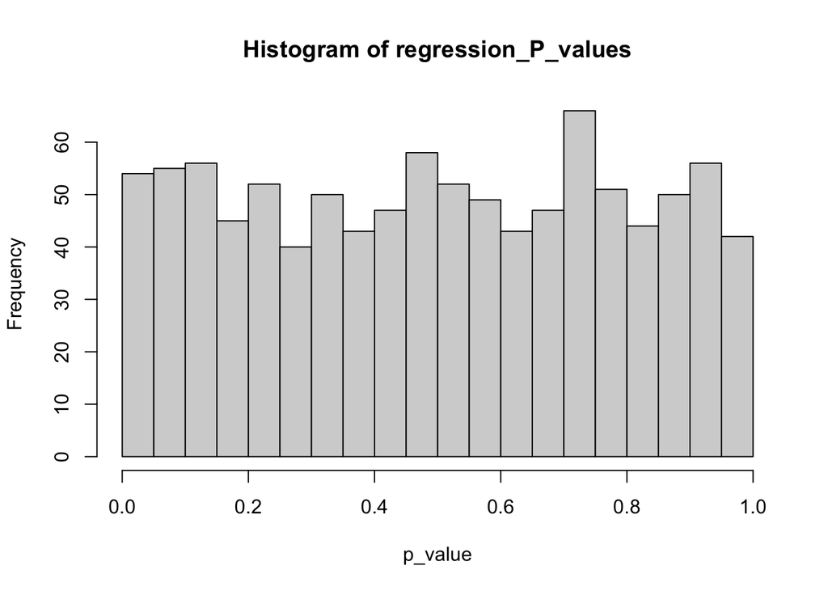

```r
regression_P_values <- summary(regression)$coefficient[,4]
hist(regression_P_values,
     breaks = seq(0 , 1 , 0.05),
     xlab = "p_value")
```

#### 5. How many “significant” variables do you expect to find knowing how the data was generated? How many “significant” variables does the regression yield if alpha = 0.01? What does this tell us?

I think we are expecting to see

1000 X 0.01 = 10

significant variables, the reason is that given the way the Xs are being generated, there should not be able to predict Y values, given that we are using 1% significant level, there’s 1% possibility that we erroneously identify the underlying variable as significant, as there are totally 1000 variables, we multiply 1% by 1000, which gives us 10.

```r
### turn P-value matrix into vector
p_value_vector <- as.vector(regression_P_values)

### return numbers of p-values that are smaller than 0.01 (significant under 1% significant level)
length(p_value_vector[p_value_vector < 0.01])
```

```
## [1] 13
```

13 significant values under alpha = 0.01

It tells us that there might be some false discoveries which results in number of discoveries different from more the theoretical significant variables.

#### 6. Given the p values you find, use the BH procedure to control the FDR with a q of 0.1. How many “true” discoveries do you estimate?

```r
### adjust p-values using p.adjust with method = Benjamini & Hochberg
new_p_values = p.adjust(p_value_vector,
             method = "BH")

### try to get dataframe with p_values < 0.1
as.data.frame(new_p_values) %>% filter(new_p_values<0.1)
```

```
## [1] new_p_values
## <0 rows> (or 0-length row.names)
```

As none of the adjusted p-values are smaller than 0.1, we conclude that there is 0 true discovery being estimated.

#### 7.Explore the “autos.csv” data. Include any metrics and / or plots you find interesting.

```r
### read data from csv
auto <- read.csv("autos.csv")

### print the column names
colnames(auto)
```

```
##  [1] "make"              "fuel_type"         "aspiration"
##  [4] "num_of_doors"      "body_style"        "drive_wheels"
##  [7] "engine_location"   "wheel_base"        "length"
## [10] "width"             "height"            "curb_weight"
## [13] "engine_type"       "num_of_cylinders"  "engine_size"
## [16] "fuel_system"       "bore"              "stroke"
## [19] "compression_ratio" "horsepower"        "peak_rpm"
## [22] "city_mpg"          "highway_mpg"       "price"
```

```r
### regress price with everything else
auto_regression_everything <- lm(price~. , data = auto)
summary(lm(price~. , data = auto))
```

```
##
## Call:
## lm(formula = price ~ ., data = auto)
##
## Residuals:
##     Min      1Q  Median      3Q     Max
## -3599.8  -989.6     0.0   838.2  8663.6
##
## Coefficients: (2 not defined because of singularities)
##                       Estimate Std. Error t value Pr(>|t|)
## (Intercept)         -1.082e+04  1.790e+04  -0.605 0.546359
## makeaudi            -1.098e+02  2.077e+03  -0.053 0.957900
## makebmw              6.279e+03  2.010e+03   3.125 0.002164 **
## makechevrolet       -4.753e+03  2.295e+03  -2.071 0.040205 *
## makedodge           -4.996e+03  1.901e+03  -2.627 0.009563 **
## makehonda           -1.534e+03  2.222e+03  -0.691 0.490957
## makeisuzu           -3.213e+03  2.543e+03  -1.264 0.208387
## makejaguar          -1.538e+03  2.571e+03  -0.598 0.550808
## makemazda           -1.811e+03  1.680e+03  -1.078 0.282928
## makemercedes-benz    2.773e+03  2.251e+03   1.232 0.220188
## makemercury         -1.978e+03  2.732e+03  -0.724 0.470305
## makemitsubishi      -5.593e+03  1.880e+03  -2.976 0.003445 **
## makenissan          -2.875e+03  1.633e+03  -1.760 0.080512 .
## makepeugot          -9.279e+03  3.313e+03  -2.801 0.005822 **
## makeplymouth        -5.227e+03  1.876e+03  -2.786 0.006076 **
## makeporsche          5.374e+03  2.718e+03   1.977 0.050019 .
## makesaab             2.225e+03  1.869e+03   1.190 0.235958
## makesubaru          -1.728e+03  1.954e+03  -0.884 0.378258
## maketoyota          -2.898e+03  1.553e+03  -1.866 0.064099 .
## makevolkswagen      -1.788e+03  1.731e+03  -1.033 0.303490
## makevolvo           -8.789e+02  2.043e+03  -0.430 0.667685
## fuel_typegas        -1.484e+04  6.100e+03  -2.433 0.016254 *
## aspirationturbo      2.179e+03  8.372e+02   2.603 0.010230 *
## num_of_doorstwo     -3.635e+02  4.977e+02  -0.730 0.466367
## body_stylehardtop   -3.086e+03  1.206e+03  -2.560 0.011533 *
## body_stylehatchback -4.011e+03  1.110e+03  -3.614 0.000420 ***
## body_stylesedan     -3.391e+03  1.206e+03  -2.811 0.005647 **
## body_stylewagon     -3.562e+03  1.317e+03  -2.704 0.007698 **
## drive_wheelsfwd     -8.637e+02  9.451e+02  -0.914 0.362340
## drive_wheelsrwd     -4.638e+02  1.248e+03  -0.372 0.710739
```

[output cut: 16 more lines]

```
## fuel_systemspdi      1.243e+03  1.890e+03   0.658 0.511740
## fuel_systemspfi      3.514e+03  3.143e+03   1.118 0.265533
## bore                -3.668e+03  1.489e+03  -2.463 0.014973 *
## stroke              -1.188e+03  9.225e+02  -1.288 0.199801
## compression_ratio   -1.054e+03  4.325e+02  -2.436 0.016096 *
## horsepower          -5.590e+00  2.180e+01  -0.256 0.797992
## peak_rpm             2.350e+00  6.542e-01   3.592 0.000453 ***
## city_mpg             3.818e+01  1.377e+02   0.277 0.781955
## highway_mpg          1.273e+02  1.194e+02   1.066 0.288479
## ---
## Signif. codes:  0 '***' 0.001 '**' 0.01 '*' 0.05 '.' 0.1 ' ' 1
##
## Residual standard error: 1819 on 140 degrees of freedom
## Multiple R-squared:  0.9631, Adjusted R-squared:  0.9495
## F-statistic: 70.35 on 52 and 140 DF,  p-value: < 2.2e-16
```

Scatter plot for lm(price ~ make)

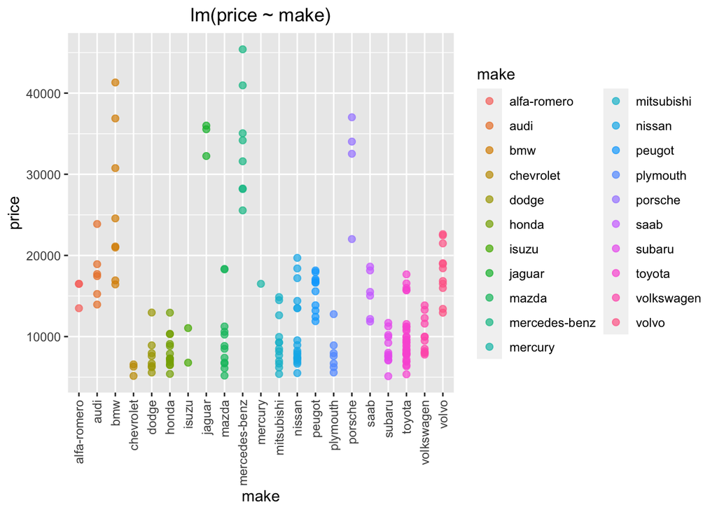

```r
library(ggplot2)

ggplot(auto , aes(x = make , y = price , color = make)) +
  geom_point(size = 2 , alpha = 0.7) +
  theme(axis.text.x = element_text(angle = 90, vjust = 0.5, hjust=1) ,
        plot.title = element_text(hjust = 0.5)) +
  ggtitle("lm(price ~ make)")
```

test p-value of lm(price~make)

```r
summary(lm(price~make , data = auto))
```

```
##
## Call:
## lm(formula = price ~ make, data = auto)
##
## Residuals:
##     Min      1Q  Median      3Q     Max
## -9688.8 -2147.8  -582.5  1409.0 15196.3
##
## Coefficients:
##                    Estimate Std. Error t value Pr(>|t|)
## (Intercept)       15498.333   2216.330   6.993 5.72e-11 ***
## makeaudi           2360.833   2714.438   0.870  0.38566
## makebmw           10620.417   2598.877   4.087 6.71e-05 ***
## makechevrolet     -9491.333   3134.364  -3.028  0.00284 **
## makedodge         -7708.208   2598.877  -2.966  0.00345 **
## makehonda         -7313.641   2458.797  -2.974  0.00336 **
## makeisuzu         -6581.833   3504.325  -1.878  0.06205 .
## makejaguar        19101.667   3134.364   6.094 7.01e-09 ***
## makemazda         -5646.333   2477.932  -2.279  0.02392 *
## makemercedes-benz 18148.667   2598.877   6.983 6.03e-11 ***
## makemercury        1004.667   4432.659   0.227  0.82096
## makemitsubishi    -6258.564   2458.797  -2.545  0.01179 *
## makenissan        -5082.667   2393.910  -2.123  0.03517 *
## makepeugot           -9.242   2500.357  -0.004  0.99705
## makeplymouth      -7534.905   2649.021  -2.844  0.00499 **
## makeporsche       15902.167   2931.929   5.424 1.95e-07 ***
## makesaab           -275.000   2714.438  -0.101  0.91942
## makesubaru        -6957.083   2477.932  -2.808  0.00557 **
## maketoyota        -5612.521   2317.893  -2.421  0.01650 *
## makevolkswagen    -5420.833   2477.932  -2.188  0.03004 *
## makevolvo          2564.848   2500.357   1.026  0.30643
## ---
## Signif. codes:  0 '***' 0.001 '**' 0.01 '*' 0.05 '.' 0.1 ' ' 1
##
## Residual standard error: 3839 on 172 degrees of freedom
## Multiple R-squared:  0.7982, Adjusted R-squared:  0.7748
## F-statistic: 34.03 on 20 and 172 DF,  p-value: < 2.2e-16
```

scatter plot for lm(price ~ body_style)

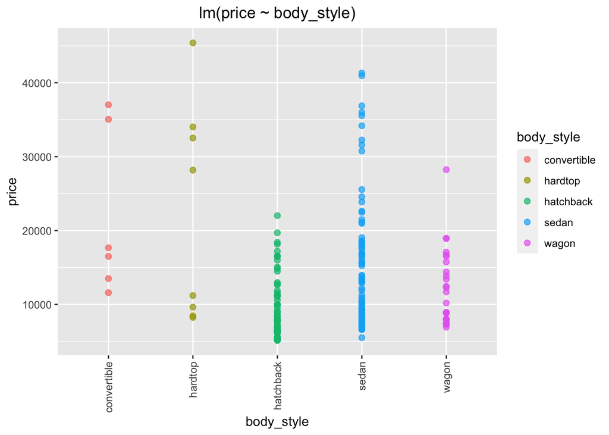

```r
ggplot(auto , aes(x = body_style , y = price , color = body_style)) +
  geom_point(size = 2 , alpha = 0.7) +
  theme(axis.text.x = element_text(angle = 90, vjust = 0.5, hjust=1) ,
        plot.title = element_text(hjust = 0.5)) +
  ggtitle("lm(price ~ body_style)")
```

test p-value of lm(price~body_style)

```r
summary(lm(price~body_style , data = auto))
```

```
##
## Call:
## lm(formula = price ~ body_style, data = auto)
##
## Residuals:
##    Min     1Q Median     3Q    Max
## -13960  -5015  -1807   3250  26751
##
## Coefficients:
##                     Estimate Std. Error t value Pr(>|t|)
## (Intercept)            21890       3056   7.163 1.74e-11 ***
## body_stylehardtop        318       4043   0.079 0.937390
## body_stylehatchback   -12126       3198  -3.791 0.000202 ***
## body_stylesedan        -7327       3154  -2.323 0.021258 *
## body_stylewagon        -9390       3417  -2.748 0.006576 **
## ---
## Signif. codes:  0 '***' 0.001 '**' 0.01 '*' 0.05 '.' 0.1 ' ' 1
##
## Residual standard error: 7486 on 188 degrees of freedom
## Multiple R-squared:  0.1614, Adjusted R-squared:  0.1436
## F-statistic: 9.045 on 4 and 188 DF,  p-value: 1.055e-06
```

scatter plot for lm(price ~ drive_wheels)

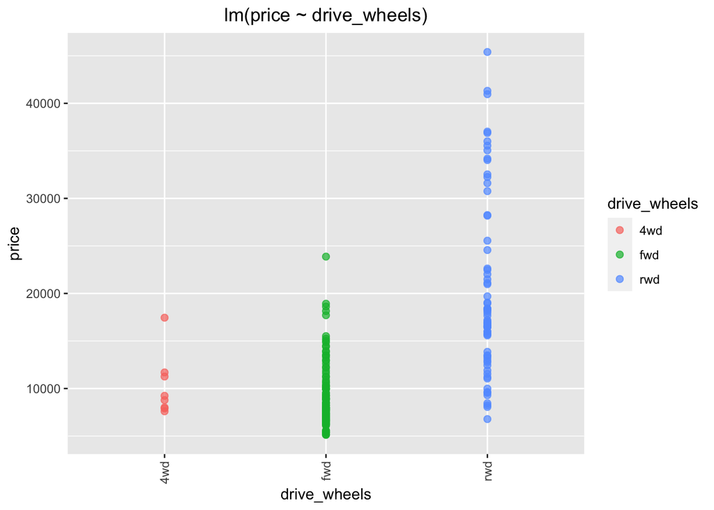

```r
ggplot(auto , aes(x = drive_wheels , y = price , color = drive_wheels)) +
  geom_point(size = 2 , alpha = 0.7) +
  theme(axis.text.x = element_text(angle = 90, vjust = 0.5, hjust=1) ,
        plot.title = element_text(hjust = 0.5)) +
  ggtitle("lm(price ~ drive_wheels)")
```

test p-value of lm(price~drive_wheels)

```r
summary(lm(price~drive_wheels , data = auto))
```

```
##
## Call:
## lm(formula = price ~ drive_wheels, data = auto)
##
## Residuals:
##    Min     1Q Median     3Q    Max
## -13352  -3002  -1456   1467  25263
##
## Coefficients:
##                 Estimate Std. Error t value Pr(>|t|)
## (Intercept)        10241       2189   4.679 5.47e-06 ***
## drive_wheelsfwd    -1010       2264  -0.446    0.656
## drive_wheelsrwd     9896       2309   4.286 2.89e-05 ***
## ---
## Signif. codes:  0 '***' 0.001 '**' 0.01 '*' 0.05 '.' 0.1 ' ' 1
##
## Residual standard error: 6191 on 190 degrees of freedom
## Multiple R-squared:  0.4204, Adjusted R-squared:  0.4143
## F-statistic:  68.9 on 2 and 190 DF,  p-value: < 2.2e-16
```

test p-value of lm(price~engine_type)

```r
summary(lm(price~engine_type , data = auto))
```

```
##
## Call:
## lm(formula = price ~ engine_type, data = auto)
##
## Residuals:
##    Min     1Q Median     3Q    Max
## -11599  -4523  -2426   2272  29693
##
## Coefficients:
##                 Estimate Std. Error t value Pr(>|t|)
## (Intercept)        18116       2111   8.582 3.47e-15 ***
## engine_typel       -3489       2986  -1.169  0.24405
## engine_typeohc     -6494       2199  -2.953  0.00355 **
## engine_typeohcf    -4378       2832  -1.546  0.12387
## engine_typeohcv     6982       2928   2.385  0.01808 *
## ---
## Signif. codes:  0 '***' 0.001 '**' 0.01 '*' 0.05 '.' 0.1 ' ' 1
##
## Residual standard error: 7313 on 188 degrees of freedom
## Multiple R-squared:  0.1997, Adjusted R-squared:  0.1827
## F-statistic: 11.73 on 4 and 188 DF,  p-value: 1.591e-08
```

#### 8.Create a linear regression model to predict price. Explain your model.

```r
### getting all the p_values are significant
auto_p_value <- summary(auto_regression_everything)$coefficient[,4]
auto_p_value[auto_p_value < 0.01]
```

```
##             makebmw           makedodge      makemitsubishi          makepeugot
##        2.164418e-03        9.562677e-03        3.445047e-03        5.822013e-03
##        makeplymouth body_stylehatchback     body_stylesedan     body_stylewagon
##        6.075875e-03        4.196623e-04        5.647105e-03        7.698295e-03
## engine_locationrear          wheel_base         curb_weight         engine_size
##        1.180588e-03        1.934476e-03        2.753473e-03        4.814065e-06
##            peak_rpm
##        4.529330e-04
```

Combing with the individual tests performed on categorical data in the previous section following are the columns identified:

1. Make
2. Body_style
3. engine_location
4. wheel_base
5. curb_weight
6. engine_size
7. peak_rpm
8. drive wheels

Linear model

```r
auto_model <- lm(price ~ make + body_style + engine_location + wheel_base + curb_weight +
                   engine_size + peak_rpm + drive_wheels , data = auto)

summary(auto_model)
```

```
##
## Call:
## lm(formula = price ~ make + body_style + engine_location + wheel_base +
##     curb_weight + engine_size + peak_rpm + drive_wheels, data = auto)
##
## Residuals:
##     Min      1Q  Median      3Q     Max
## -4657.6 -1064.2     0.0   879.4  9878.0
##
## Coefficients:
##                       Estimate Std. Error t value Pr(>|t|)
## (Intercept)         -20872.130   5752.720  -3.628 0.000383 ***
## makeaudi              2081.014   1833.081   1.135 0.257956
## makebmw               7587.939   1633.659   4.645 7.04e-06 ***
## makechevrolet         -462.861   1917.465  -0.241 0.809558
## makedodge            -2273.421   1676.792  -1.356 0.177056
## makehonda            -1789.930   1654.244  -1.082 0.280860
## makeisuzu            -3296.153   2004.202  -1.645 0.101999
## makejaguar            3012.582   2108.204   1.429 0.154947
## makemazda            -1016.588   1575.953  -0.645 0.519805
## makemercedes-benz     7231.554   1753.263   4.125 5.94e-05 ***
## makemercury           -134.623   2527.016  -0.053 0.957580
## makemitsubishi       -2991.426   1616.472  -1.851 0.066061 .
## makenissan           -2198.033   1541.606  -1.426 0.155860
## makepeugot           -2325.073   1748.411  -1.330 0.185458
## makeplymouth         -2621.477   1667.085  -1.572 0.117800
## makeporsche           5654.983   2485.667   2.275 0.024223 *
## makesaab               569.418   1796.593   0.317 0.751697
## makesubaru           -1897.225   1620.905  -1.170 0.243540
## maketoyota           -2383.149   1452.476  -1.641 0.102802
## makevolkswagen       -1452.424   1592.369  -0.912 0.363072
## makevolvo              296.208   1652.199   0.179 0.857942
## body_stylehardtop    -2763.376   1254.519  -2.203 0.029034 *
## body_stylehatchback  -2575.270   1106.490  -2.327 0.021188 *
## body_stylesedan      -2636.448   1135.343  -2.322 0.021477 *
## body_stylewagon      -3903.144   1236.351  -3.157 0.001903 **
## engine_locationrear   9145.607   2544.840   3.594 0.000433 ***
## wheel_base             113.313     65.128   1.740 0.083794 .
## curb_weight              4.845      1.073   4.514 1.22e-05 ***
## engine_size             64.273     11.410   5.633 7.73e-08 ***
## peak_rpm                 1.174      0.464   2.531 0.012343 *
## drive_wheelsfwd       -440.490    941.981  -0.468 0.640688
## drive_wheelsrwd       -522.127   1094.073  -0.477 0.633844
## ---
## Signif. codes:  0 '***' 0.001 '**' 0.01 '*' 0.05 '.' 0.1 ' ' 1
##
## Residual standard error: 2047 on 161 degrees of freedom
## Multiple R-squared:  0.9463, Adjusted R-squared:  0.9359
## F-statistic: 91.49 on 31 and 161 DF,  p-value: < 2.2e-16
```

#### 9. Why might false discoveries be an issue?

Because there are some times where we have to be especially careful about the variables we choose to put into the model and sometimes it’s very costly to gather all the data, and any additional redundant variable can become a big burden.

#### 10. Use the BH procedure to control the FDR with a q of 0.1. How many true discoveries do you estimate? Plot the cutoff line together with the significant and insignificant p-values.

```r
library(sgof)
auto_model_p_values <- as.vector(summary(auto_model)$coefficient[2:nrow(summary(auto_model)$coefficient),4])
res <- BH(auto_model_p_values , alpha = 0.1)

res$Rejections
```

```
## [1] 11
```

11 true discoveries

```r
### Turn p-values into dataframe
auto_p_value_df <- as.data.frame(summary(auto_model)$coefficient[,4])
### rename column
colnames(auto_p_value_df) <- "p-value"

### sort dataframe
sorted_auto_df <- auto_p_value_df[order(auto_p_value_df$'p-value') ,, drop = FALSE]

### extract left 11 varaibles + coefficient
top_11_df <- head(sorted_auto_df , 12)

###Final model
top_11_df
```

```
##                          p-value
## engine_size         7.726311e-08
## makebmw             7.035423e-06
## curb_weight         1.224135e-05
## makemercedes-benz   5.936942e-05
## (Intercept)         3.827708e-04
## engine_locationrear 4.327679e-04
## body_stylewagon     1.903419e-03
## peak_rpm            1.234332e-02
## body_stylehatchback 2.118770e-02
## body_stylesedan     2.147670e-02
## makeporsche         2.422320e-02
## body_stylehardtop   2.903403e-02
```

plot cutoff line

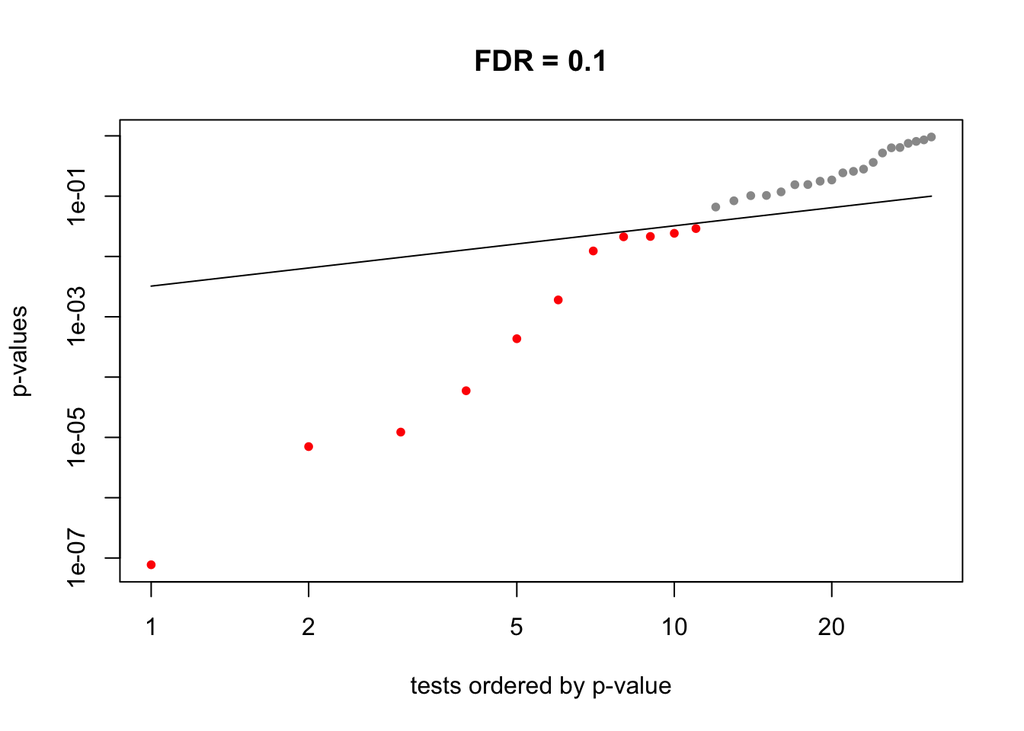

```
## [1] 0.02903403
```

```r
fdr <- function(pvals, q, plotit=TRUE){
  pvals <- pvals[!is.na(pvals)]
  N <- length(pvals)

  k <- rank(pvals, ties.method="min")
  alpha <- max(pvals[ pvals <= (q*k/N) ])

  if(plotit){
    sig <- factor(pvals <= alpha)
    o <- order(pvals)
    plot(pvals[o], log="xy", col=c("grey60","red")[sig[o]], pch=20,
      ylab="p-values", xlab="tests ordered by p-value", main = paste('FDR =',q))
    lines(1:N, q*(1:N) / N)
  }

  return(alpha)
}

fdr(auto_model_p_values , 0.1)
```